# Solución Primer Evaluación Parcial

**Resuelve los siguientes ejercicios**

1. Resolver las siguientes ecuaciones de primer grsdo
   1. $-\frac{7}{8}x - \frac{6}{7} = \frac{5}{6}x - \frac{3}{5}$
   2. $\frac{3}{4}-\left\{-[\frac{5}{6}(\frac{3}{4}x-\frac{4}{5})+\frac{7}{8}(\frac{2}{3}x-\frac{5}{6})]\right\}=\frac{9}{10}(\frac{4}{5}x+\frac{6}{15})$

**Solución:**

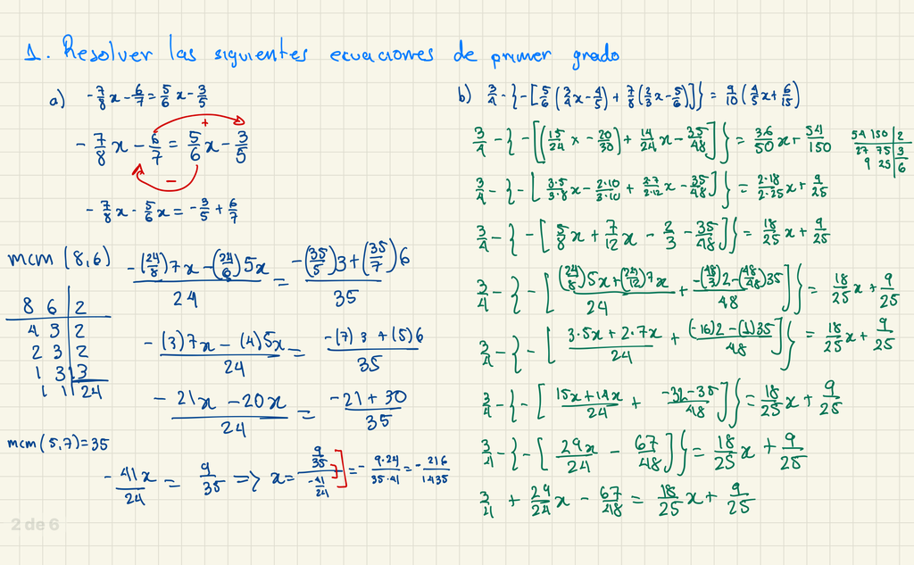

a)

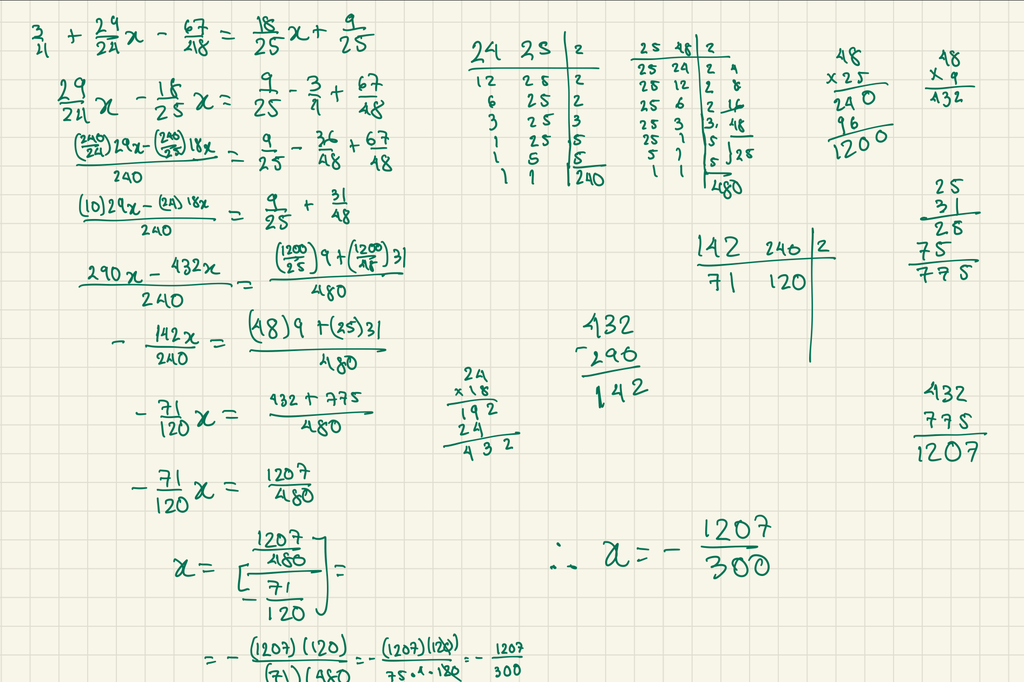

b)

2. Resolver las siguientes desigualdades de primer grado
   1. $2x-5<x-3$
   2. $-\frac{1}{2}x + \frac{1}{3} \geq -\frac{3}{4}x - \frac{1}{6}$

**Solución:**

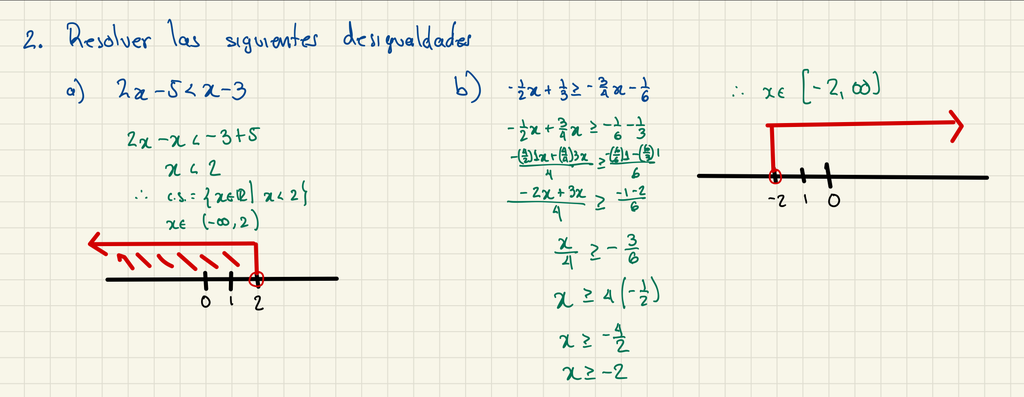

a) y b)

3. Resolver las siguientes desigualdades dobles
   1. $-\frac{3}{4}\leq -\frac{1}{2}x+\frac{1}{4}\leq \frac{1}{4}$

**Solución:**

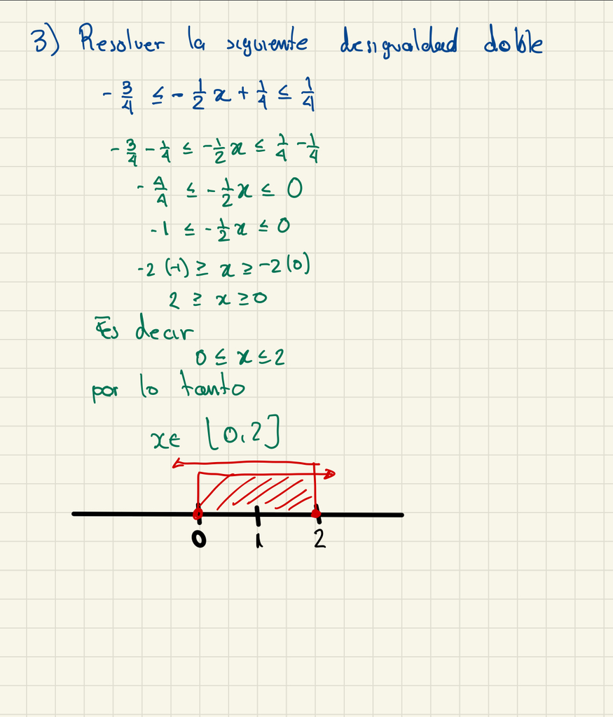

a)

4. Resolver las siguientes desigualdades de valor absoluto
   1. $|\frac{1}{2}x-\frac{1}{4}|> \frac{5}{4}$
   2. $|{\frac{1}{4}x+\frac{6}{9}}| \leq \frac{3}{4}$

**Solución:**

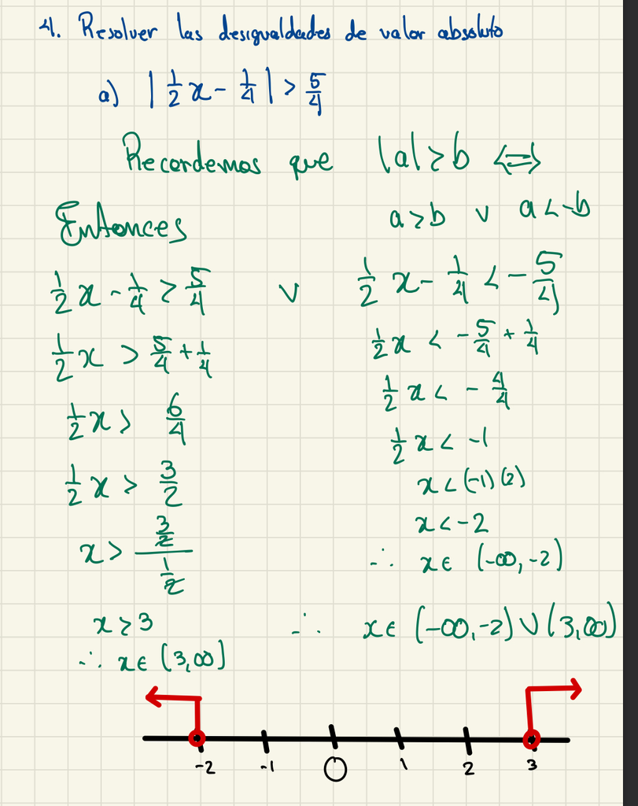

a)

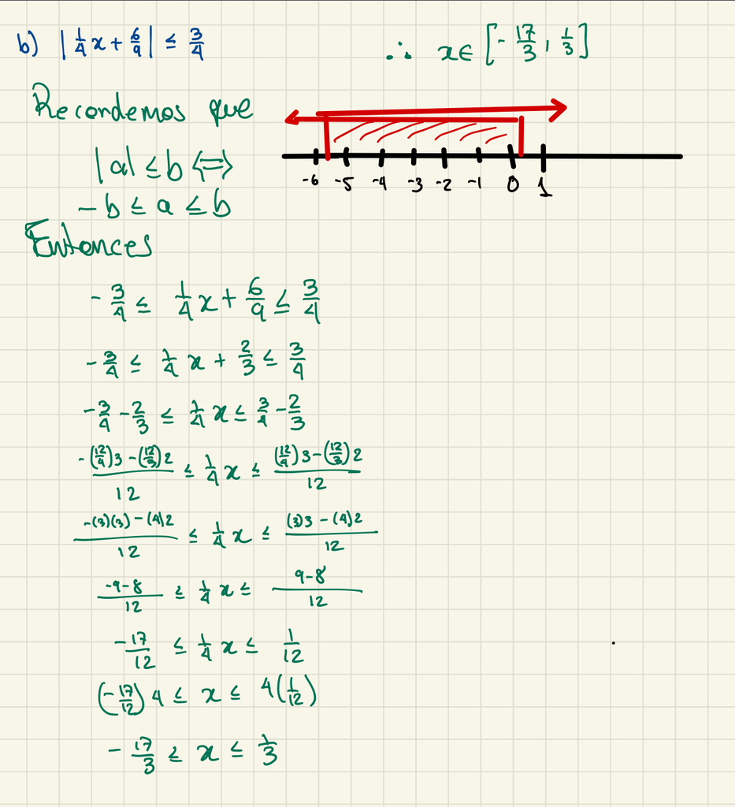

b)

5. Resolver las siguentes desigualdades de segundo grado
   1. $4x^2-12x+9\geq 0$
   2. $\frac{1}{3}x^2+\frac{5}{3}x+2\leq0$

**Solución:**

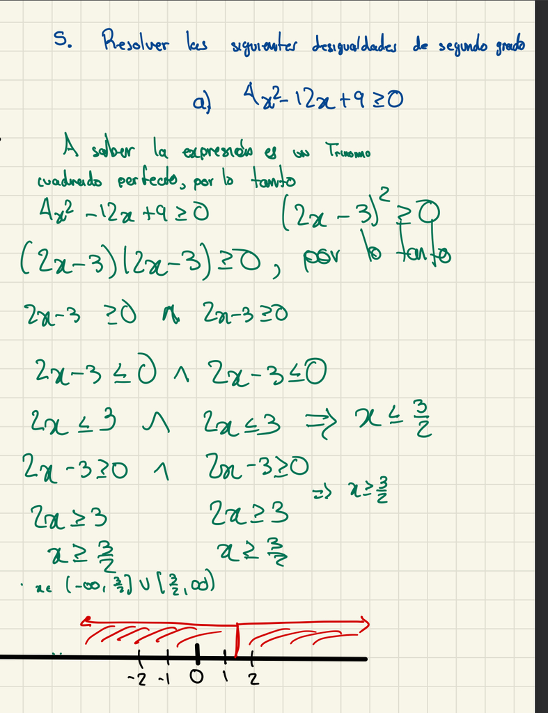

a)

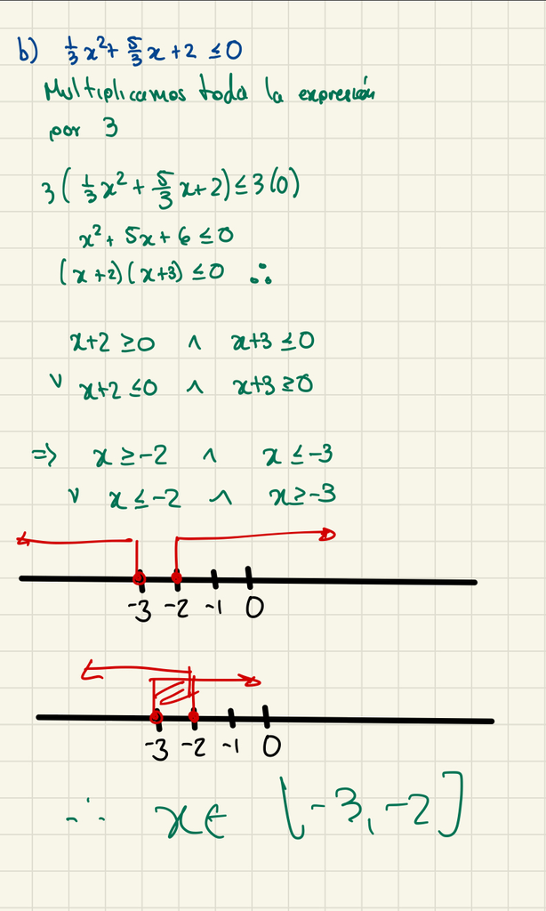

b)

**La suma total de puntos a considerar es de 10**